# Exploring Weather Trends

Data Analysis Nano-Degree - Udacity

Aviad Giat

Feb 9, 2019

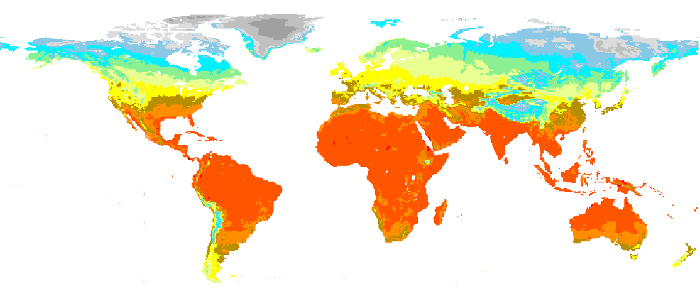

The full analysis of this project can be read as on my [website.](https://u4see.org/data/Weather%20Trends/weather_trends.pdf)  
A Github repository with all the files and folders is available [here.](https://github.com/AviadGiat/data-analysis/tree/master/Explore%20Weather%20Trends)

### **Outline**

I chose to do this project on the biggest city next to me, which is San Francisco, California. I added 3 more cities to this analysis to compare the average weekly temperatures in SF with them.  
To accomplish the visualization of this project I used a few SQL lines to download the global average temperatures and the average temperatures in: San Francisco; Rio De Janeiro; London; and Helsinki. I downloaded the raw temperature data from Udacity’s server to my machine;  
I used R to write the code and Rstudio to produce the .pdf file. With R I created a new column for each table (xls file in this stage) with the weekly average from the 7th record until the last one. This left 6 empty rows (first lines that do not have 7 days prior to its date). Before plotting the data I merged the datasets mentioned above to one dataframe called ‘weather’. To plot the data I used the package ggplot2, which I worked with before and is a great tool for fast and easy plotting.

The SQL line I used on Udacity’s server to retrieve the data I wanted:

##### select * from city_data where city = ‘San Francisco’; select * from global_data; select * from city_data where city = ‘Helsinki’ select * from city_data where city = ‘Rio De Janeiro’ select * from city_data where city = ‘London’ select * from city_data where city = ‘San Francisco’

### **A quick examination of the dataset**

The first lines of the merged dataset

```
##   year   city        country weekly_avg_london weekly_avg_global
## 1 1749 London United Kingdom              7.34                NA
##   weekly_avg_sf weekly_avg_helsinki weekly_avg_rio
## 1            NA                  NA             NA
```

Basic statistics and structure of the different variables

```
##       year          city             country          weekly_avg_london
##  Min.   :1749   Length:865         Length:865         Min.   : 7.340
##  1st Qu.:1850   Class :character   Class :character   1st Qu.: 9.180
##  Median :1905   Mode  :character   Mode  :character   Median : 9.400
##  Mean   :1900                                         Mean   : 9.431
##  3rd Qu.:1959                                         3rd Qu.: 9.610
##  Max.   :2013                                         Max.   :10.780
##                                                       NA's   :600
##  weekly_avg_global weekly_avg_sf   weekly_avg_helsinki weekly_avg_rio
##  Min.   :7.190     Min.   :13.85   Min.   :0.640       Min.   :22.80
##  1st Qu.:8.090     1st Qu.:14.18   1st Qu.:3.890       1st Qu.:23.48
##  Median :8.330     Median :14.41   Median :4.160       Median :23.73
##  Mean   :8.414     Mean   :14.44   Mean   :4.229       Mean   :23.77
##  3rd Qu.:8.650     3rd Qu.:14.64   3rd Qu.:4.530       3rd Qu.:24.05
##  Max.   :9.590     Max.   :15.18   Max.   :5.850       Max.   :24.78
##  NA's   :14        NA's   :706     NA's   :600         NA's   :690
```

```
## 'data.frame':    865 obs. of  8 variables:
##  $ year               : int  1749 1750 1751 1752 1753 1754 1755 1756 1757 1758 ...
##  $ city               : chr  "London" "London" "London" "London" ...
##  $ country            : chr  "United Kingdom" "United Kingdom" "United Kingdom" "United Kingdom" ...
##  $ weekly_avg_london  : num  7.34 8.24 8.12 8.93 9.05 9.08 9.06 9.11 8.98 8.82 ...
##  $ weekly_avg_global  : num  NA NA NA NA NA NA NA 8.08 8.12 7.94 ...
##  $ weekly_avg_sf      : num  NA NA NA NA NA NA NA NA NA NA ...
##  $ weekly_avg_helsinki: num  NA NA NA NA NA NA NA NA NA NA ...
##  $ weekly_avg_rio     : num  NA NA NA NA NA NA NA NA NA NA ...
```

We can see above the years and weekly averages for San Francisco, Helsinki, London, Rio De Janeiro and for the entire Globe’s temperatures statistics. The minimum weekly average of SF was 14 degrees and the max was 15. The global weekly average temperature was 7 at the minimum and 9.5 at the maximum. We can say that San Francisco is on the warm side of the planet’s temperature distribution. Let’s examine the correlation coefficient of San Francisco and the rest of the cities.

### The correlation coefficient between the years variable and the weekly average in San Francisco

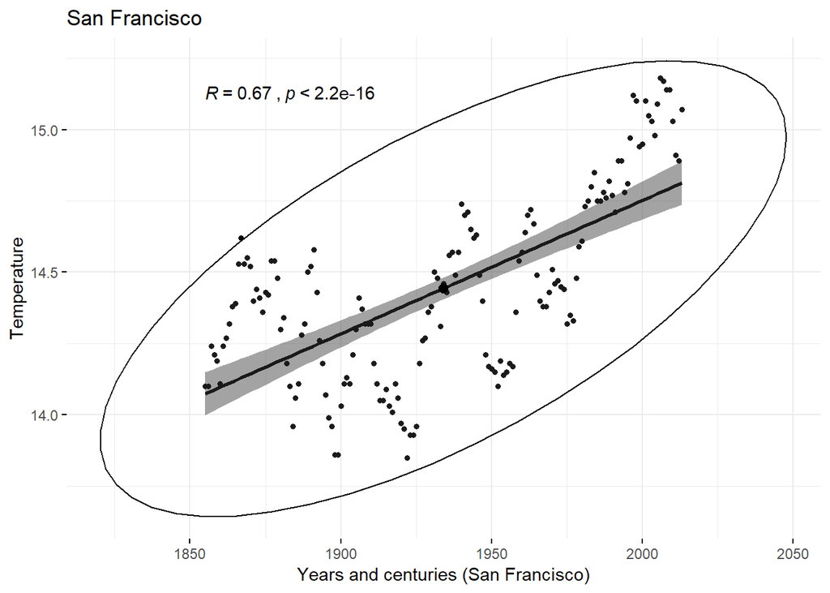

The correlation coefficient between the average temperatures in SF and the year has the value of 0.67. (1 is perfect correlation and 0 is none)  
When looking at the P level, we can see that it is much smaller than 0.5 (2.2e-16 - is the smallest number of system can show), which means that we can reject the null hypothesis and say that there is a very strong correlation between the years advancement and the rise in temperature in San Francisco.

### The correlation coefficient between the years and the weekly average in Helsinki

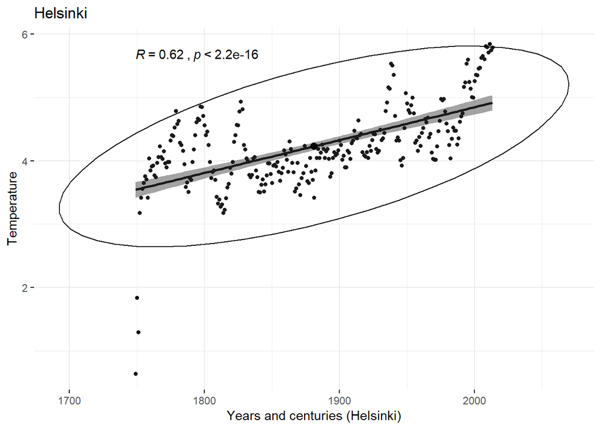

### Correlation coefficient between the years and the weekly average in Rio De Janeiro

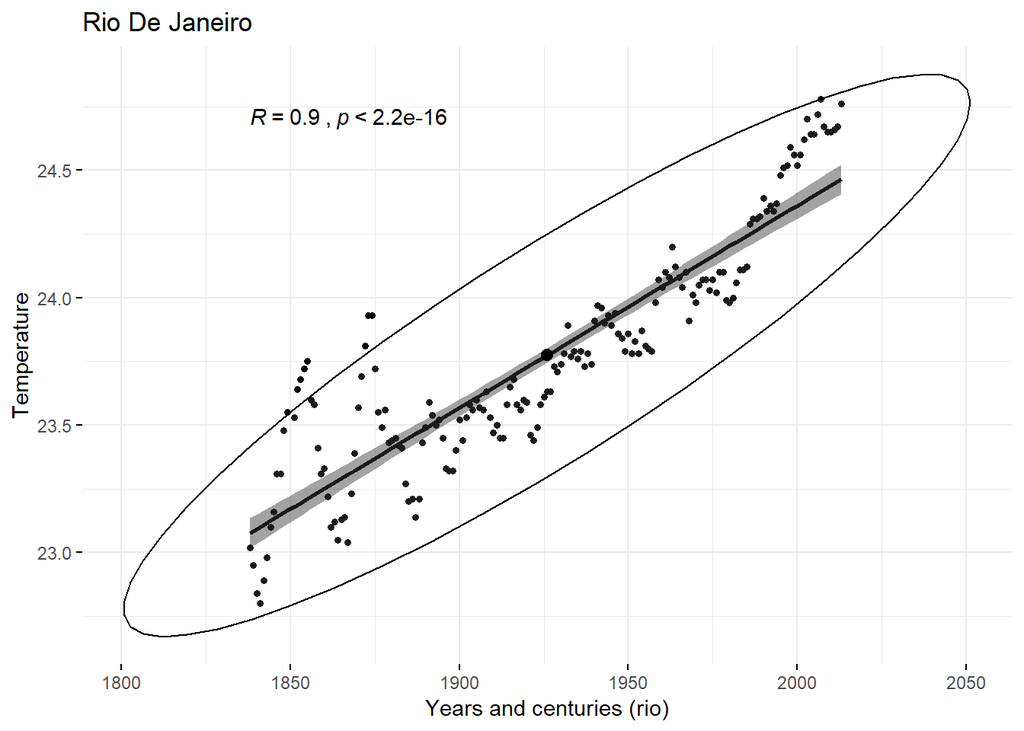

Rio De Janeiro was taken as a city from the Southern hemisphere. It has an almost perfect correlation (R = 0.9) between the years and temperatures. The P value here is also almost 0, so we reject the null hypothesis and say that there is a very strong correlation here as well.

### Correlation coefficient between the years and the weekly average in London

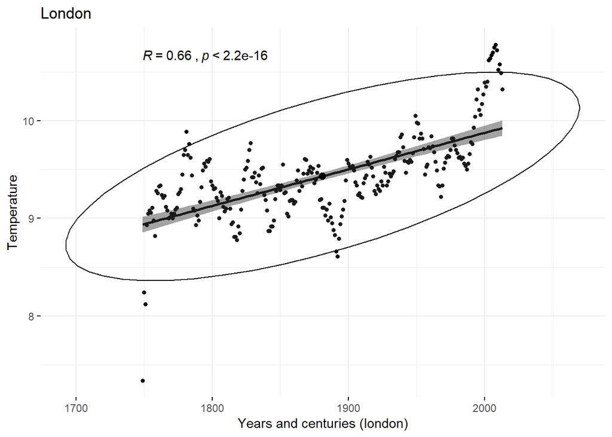

We can see above that there is a strong correlation between the years and the temperature in London, as with the previous cities. London was taken for its part in being the epicenter of the Industrial Revolution, which started in the 18th century. In the UK the Industrial Revolution during the 18th and 19th centuries was based on the use of coal. Industries were often located in towns and cities, and together with the burning of coal in homes for domestic heat, urban air pollution levels often reached very high levels. Scientists found that there is a strong correlation between air pollution and rising air temperature. So, coal pollution might have been the first reason for rising temperatures in London, as can be seen in the following chart.

How are the above look next to each other and compared to the Global temperature change throughout the years and centuries?

### **Cities VS Global weekly average temperatures**

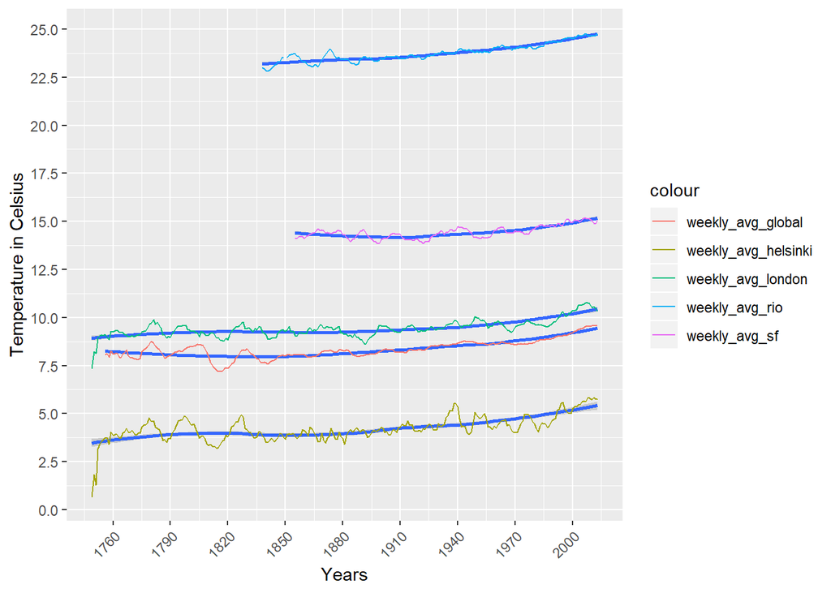

### **Cities VS Global weekly average temperatures**

```
## # A tibble: 5 x 4
## # Groups:   City [5]
##   City             Max   Min  Diff
##   <fct>          <dbl> <dbl> <dbl>
## 1 London         10.8   7.34  3.44
## 2 Global          9.59  7.19  2.40
## 3 San Francisco  15.2  13.8   1.33
## 4 Helsinki        5.85  0.64  5.21
## 5 Rio De Janeiro 24.8  22.8   1.98
```

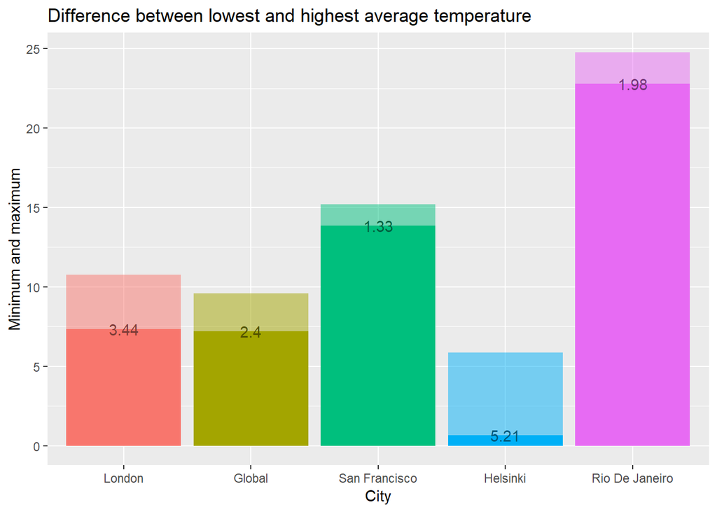

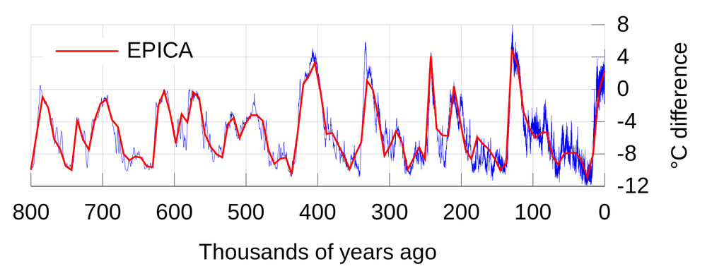

Source: [Wikipedia](https://en.wikipedia.org/wiki/Global_temperature_record)

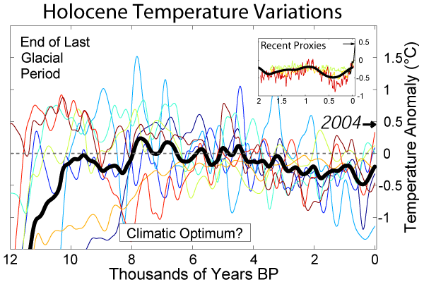

Source: [Wikipedia](https://en.wikipedia.org/wiki/Global_temperature_record)

### **Conclusion**

Finally, We can expect to have higher temperatures, both locally and globally, if all the conditions that created the above trends remain the same, in the coming years and decades.